# temp-164521281221493835

This is the first half of the module 3 assignment. The full module 3 assignment will be due on Wednesday, February 23 at 11:59 pm ET. To submit your work, please download this document as an html file and upload that to Canvas.

1. List the names of your group members, as well as any other class members you conferred with for this assignment.

> Rafael Piloto, Rex Xu, Zhuo Chen, Muyi Chen
1. In class, we derived expressions three for numerical approximations of derivatives: forward, backward, and central difference, and we wrote a function containing a for loop for each. Write a new, more efficient function that takes in $x$ and $y$ values and outputs the derivative, $dy/dx$, along with the corresponding $x$ points, but uses only array indexing and does not contain any for loops for each of the following.

(a) Forward difference

```python
import numpy as np
import matplotlib.pyplot as plt

def forward_diff(x, y):
  dy = (y[1:] - y[:-1])
  dx = (x[1:] - x[:-1])
  return dy / dx
```

(b) Backward difference

```python
def backward_diff(x, y):
  dy = (y[1:] - y[:-1])
  dx = (x[1:] - x[:-1])
  return dy / dx
```

(c) Central difference

```python
def central_diff(x, y):
  dy = (y[2:] - y[:-2])
  dx = (x[2:] - x[:-2])
  return dy / dx
```

1. Evaluate the function $y = 10 e^{-x^2 \over 2\pi} \sin(2 \pi x)$ for evenly spaced $x$ values in the range $[-2\pi,2\pi]$ with spacing $h = 0.001$. Test your new functions in question 2 by calculating the numerical derivative of $y$ using each method. Create plots for each method and to compare the output of your new functions with those from class. Be sure to add a legend and label the axes of your plots for full credit. (Note: you can access the exponental function using np.exp)

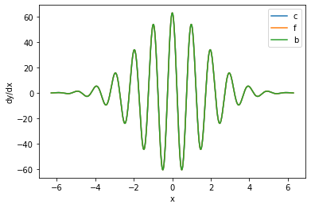

```python
h = 0.001
x = np.arange(-2 * np.pi, 2 * np.pi, h)

def f(x):
  return (10 * np.exp(-(x ** 2) / (2 * np.pi))) * np.sin(2 * np.pi * x)

y = f(x)

dy_dxf = forward_diff(x, y)
dy_dxfb = backward_diff(x, y)
dy_dxc = central_diff(x, y)

fig, ax = plt.subplots()

ax.plot(x[1:-1], dy_dxc, label="c")
ax.plot(x[:-1], dy_dxf, label="f")
ax.plot(x[1:], dy_dxfb, label="b")

ax.set(xlabel="x", ylabel="dy/dx")

plt.legend()
plt.show()
```

1. (a) Write a function that adds random noise (centered around 0) to a data set. Inputs for your function should include a data set, $y$, and and a prefactor that specifies the overall magnitude of the random noise. Your function should output a noisy $y$ vector.

```python
def noise(y, prefactor):
  return y + (prefactor * (np.random.rand(len(y)) - 0.5))
```

(b) Add noise to the function in question 3. Use prefactors = 0.01, 0.1, and 1. Make plots (with axes labeled and a legend) comparing the original data to these three noise values. How do the curves compare? (Note: the order of the curves in the plot matches the order you add them to the axes, so adding data from largest to smallest prefactor will make everything more visible)

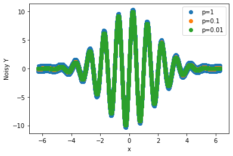

```python
fig, ax = plt.subplots()

ny_1 = noise(y, 1)
ax.plot(x, ny_1, "o", label="p=1")

ny_01 = noise(y, 0.1)
ax.plot(x, ny_01, "o", label="p=0.1")

ny_001 = noise(y, 0.01)
ax.plot(x, ny_001, "o", label="p=0.01")

ax.set(xlabel="x", ylabel="Noisy Y")

plt.legend()
plt.show()
```

> The higher the prefactor, the higher the noise. The smaller the prefactor, the smaller the noise, which resembles the original line closer.

(c) Using your central difference code, calculate the numerical derivative for each level of noise. Make plots (axes labeled and a legend) that compare the derivatives as a function of the noise level. How does the approximated derivative change as the noise is increased and why?

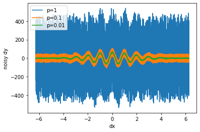

```python
dy_dx_n1 = central_diff(x, ny_1)
dy_dx_n01 = central_diff(x, ny_01)
dy_dx_n001 = central_diff(x, ny_001)

fig, ax = plt.subplots()

ax.plot(x[1:-1], dy_dx_n1, label="p=1")
ax.plot(x[1:-1], dy_dx_n01, label="p=0.1")
ax.plot(x[1:-1], dy_dx_n001, label="p=0.01")

ax.set(xlabel="dx", ylabel="noisy dy")

plt.legend()
plt.show()
```

> As the noise increases, the approximated derivative becomes more jagged with higher values (or slopes) as a result in sudden slope change from the random noise.
1. Data smoothing or filtering is a common way to reduce noise in a data set. While there are lots of ways to achieve this, one relatively simple approach is to use a moving average.

(a) Write a function that takes in a data set, $y$ and the corresponding $x$ values, and replaces each $y$-value with $z$, the average of `window_size` nearby points on each side of the specified $y$ value. For example, `z[6] = (y[5]+y[6]+y[7])/3` would replace `y[6]` and `z[7] = (y[6]+y[7]+y[8])/3` would replace `y[7]` for `window_size = 1`. Your function should also take in `window_size`, which specifies the number of points (on either side of the specified point) over which to average, and it should return the new $z$ values along with the corresponding $x$ values.

```python
def smooth(x, y, window_size):
  i = 0
  z = []
  x_new = []

  while i < len(y) - window_size + 1:
      wa = np.sum(y[i:i+window_size]) / window_size

      z.append(wa)
      x_new.append(x[i + window_size//2])

      i += 1

  return x_new, z
```

(b) Use your function to explore how the moving average affects the original (non-noisy) data set. Calculate $z$ for a `window_size` of $50, 100, 200, 400$. Plot the results (with axis labels and a legend) along with the original data. How does the window size affect the original data and why?

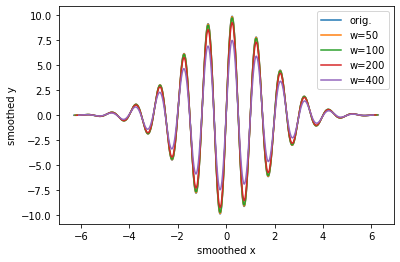

```python
ax_50, ay_50 = smooth(x, y, 50)
ax_100, ay_100 = smooth(x, y, 100)
ax_200, ay_200 = smooth(x, y, 200)
ax_400, ay_400 = smooth(x, y, 400)

fig, ax = plt.subplots()

ax.plot(x, y, label="orig.")
ax.plot(ax_50, ay_50, label="w=50")
ax.plot(ax_100, ay_100, label="w=100")
ax.plot(ax_200, ay_200, label="w=200")
ax.plot(ax_400, ay_400, label="w=400")


ax.set(xlabel="smoothed x", ylabel="smoothed y")

plt.legend()
plt.show()
```

> As the window size increases, the more values that are sampled in the average. Therefore, since we have more values closer to 0, our average height get's closer to 0.

(c) Use your function to calculate the moving average of your noisy data set with `prefactor = 1` for `window_size` values of $3, 10, 50$. Plot the results (with axis labels and a legend) along with the original data. How does the window size affect the original data and why?

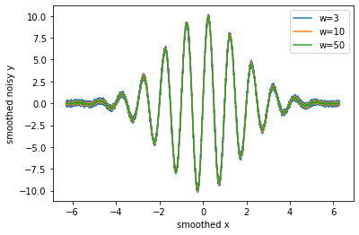

```python
fig, ax = plt.subplots()

sx_3, s_ny1_3 = smooth(x, ny_1, 3)
sx_10, s_ny1_10 = smooth(x, ny_1, 10)
sx_50, s_ny1_50 = smooth(x, ny_1, 50)

ax.plot(sx_3, s_ny1_3, label="w=3")
ax.plot(sx_10, s_ny1_10, label="w=10")
ax.plot(sx_50, s_ny1_50, label="w=50")

ax.set(xlabel="smoothed x", ylabel="smoothed noisy y")

plt.legend()
plt.show()
```

(d) Use your central difference function to calculate the derivatives of your moving-averaged data from (c). Plot the results (with axis labels and a legend) along with the derivative data. How does the moving averaged derivative compare to the derivative of the noisy data? How does the moving averaged derivative compare to the derivative of the non-noisy data? How does the value of `window_size` affect your results?

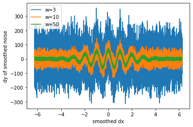

```python
fig, ax = plt.subplots()

dy_dx_syn1_3 = central_diff(np.array(sx_3), np.array(s_ny1_3))
dy_dx_syn1_10 = central_diff(np.array(sx_10), np.array(s_ny1_10))
dy_dx_syn1_50 = central_diff(np.array(sx_50), np.array(s_ny1_50))

ax.plot(sx_3[1:-1], dy_dx_syn1_3, label="w=3")
ax.plot(sx_10[1:-1], dy_dx_syn1_10, label="w=10")
ax.plot(sx_50[1:-1], dy_dx_syn1_50, label="w=50")


ax.set(xlabel = "smoothed dx", ylabel="dy of smoothed noise")
plt.legend()
plt.show()
```

(e) What do your results from (b), (c), and (d) tell us about selecting a `window_size`?

> The higher the window size, the smoother the line, but the more data lost. However, the higher the window size, the smoother the line, and the smaller the derivative. The smaller the window size, the more randomly, rigid it is, which affects creates a more variable derivative.

(f) Now take the moving average of your noisy derivative with `prefactor = 1` and plot the results for the same `window_size = 50` along with your calculation from (d) with the same `prefactor` and `window_size`. Does it matter which order you peform the moving average and derivative operations? Why or why not?

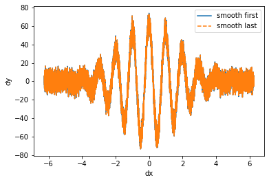

```python
fig, ax = plt.subplots()

s_x_n1, s_dy_n1 = smooth(x[1:-1], dy_dx_n1, 50)

ax.plot(sx_50[1:-1], dy_dx_syn1_50, label="smooth first")
ax.plot(s_x_n1, s_dy_n1, "--", label="smooth last")


ax.set(xlabel="dx", ylabel="dy")

plt.legend()
plt.show()
```

> No, the order in which we do them does not matter. This is because taking the derivative of noisy data produces variability which is averaged out by the moving average. Taking the derivative of smoothed data is then just the slope of the averaged line.